# Faktoranalyse O*net

## Exploratory Factor analysis of the O*NET data

Using the R package Psych

```r
library(tidyverse)
library(psych)
#install.packages("psych")



data <- as_tibble(read.delim("C:\\Users\\torm\\OneDrive - Kompetanse Norge\\Dokumenter\\GitHub\\Onet\\Faktoranalyse-O-net\\onet_rdatasett.tsv", encoding = "UTF-8"))

#meta <- c("nr", "utdanningno_yrke", "BesÃ.kstall.pr.Ã.r.utdanning.no", "andel_menn", "andel_menn_0_40", "antall", "interesse")
meta <- c("nr", "utdanningno_yrke", "Besøkstall.pr.år.utdanning.no", "andel_menn", "andel_menn_0_40", "antall", "interesse")


da <- data[,!names(data) %in% meta] #removing meta data

#Combined analysis
all <- da
names(all) <- str_split(names(all),"\\.\\.\\.", simplify = T)[,2] #simplify colnames
#names(all) <- seq_along(lengths(names(all)))
```

Start looking at data. Using all 161 variables and 301 observations (job descriptions)

Descriptive analysis and graphical test for normality (requirement for factor analysis).

```r
(dec <- describe(all)) # test normality assumptions. We want skew and kurtosis = 0.
```

| vars | n | mean | sd | median | trimmed | mad | min | max | range | skew | kurtosis | se |
| --- | --- | --- | --- | --- | --- | --- | --- | --- | --- | --- | --- | --- |
| 1 | 301 | 75.00 | 8.75 | 79.01 | 75.57 | 6.33 | 49.09 | 96.62 | 47.53 | -0.65 | -0.28 | 0.50 |
| 2 | 301 | 70.38 | 11.72 | 74.84 | 71.14 | 11.11 | 36.81 | 96.79 | 59.98 | -0.50 | -0.69 | 0.68 |
| 3 | 301 | 74.15 | 9.32 | 77.20 | 74.51 | 7.11 | 44.14 | 97.22 | 53.08 | -0.45 | -0.47 | 0.54 |
| 4 | 301 | 66.16 | 12.63 | 67.05 | 66.99 | 15.38 | 34.00 | 92.37 | 58.37 | -0.39 | -0.86 | 0.73 |
| 5 | 301 | 59.12 | 10.85 | 59.48 | 59.21 | 10.60 | 29.59 | 84.46 | 54.86 | -0.10 | -0.44 | 0.63 |
| 6 | 301 | 58.10 | 11.23 | 59.17 | 58.09 | 10.98 | 29.07 | 86.87 | 57.80 | -0.03 | -0.40 | 0.65 |
| 7 | 301 | 72.58 | 8.98 | 74.25 | 72.68 | 8.02 | 47.29 | 99.79 | 52.51 | -0.09 | -0.12 | 0.52 |
| 8 | 301 | 70.37 | 9.24 | 72.08 | 70.67 | 11.14 | 44.96 | 89.63 | 44.66 | -0.26 | -1.08 | 0.53 |
| 9 | 301 | 69.04 | 10.11 | 69.16 | 69.05 | 14.16 | 46.86 | 89.98 | 43.12 | 0.01 | -1.16 | 0.58 |
| 10 | 301 | 67.27 | 7.05 | 67.03 | 67.19 | 7.75 | 42.53 | 79.99 | 37.46 | 0.00 | -0.61 | 0.41 |

[output cut: 151 more lines]

```
Call: mardia(x = all)

Mardia tests of multivariate skew and kurtosis
Use describe(x) the to get univariate tests
n.obs = 301   num.vars =  161
b1p =  14332.33   skew =  719005.4  with probability  <=  2.5e-18
 small sample skew =  726260.7  with probability <=  3.2e-49
b2p =  26154.45   kurtosis =  -3.35  with probability <=  8e-04
```

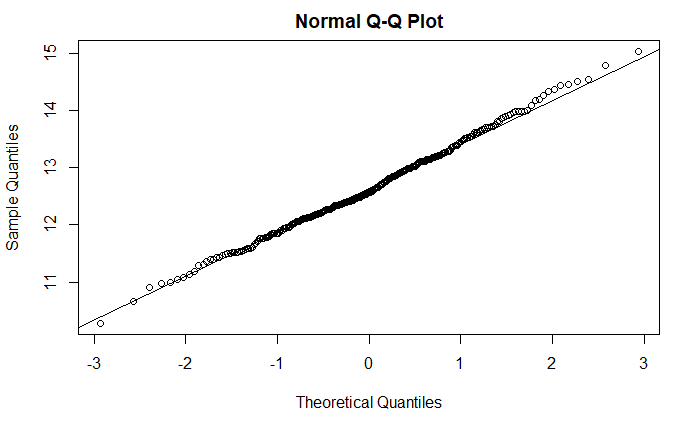

```r
mardia(all) #mardia is a test for normality
```

Some issues with non-normality but does not look too bad graphically

Generating the correlation matrix and a scree plot + parallel analysis for deciding the number of factors

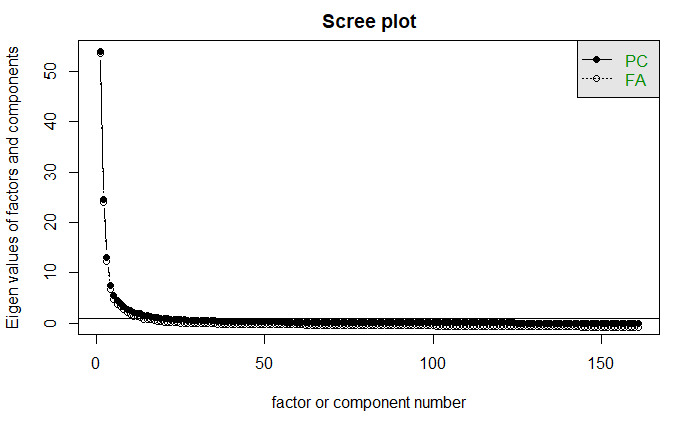

```r
S <- cor(all, method = "pearson")

scree(S)
```

```
Parallel analysis suggests that the number of factors =  11  and the number of components =  10
```

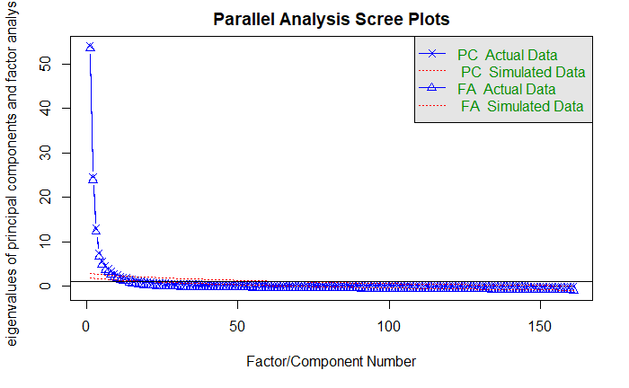

```r
fa.parallel(x= S, n.obs = 301)
```

## How many factors?

Parallel analysiys and Kaiser-Guttman rule suggest around 10 factors. Looking for the elbow gives 4 factors

### Running a 10 factor model

```r
#(efamodel1 <- fa(r=S, nfactors = 10,  fm= "minres", n.obs = 301, max.iter = 2000)) #No convergence
(efamodel1.2 <- fa(r=S, nfactors = 10,  fm= "ml", n.obs = 301)) #Changing to ML estimator
```

```
Factor Analysis using method =  ml
Call: fa(r = S, nfactors = 10, n.obs = 301, fm = "ml")
Standardized loadings (pattern matrix) based upon correlation matrix
```

|  | ML2 | ML1 | ML4 | ML3 | ML8 | ML9 | ML7 | ML6 | ML5 | ML10 | h2 | u2 | com |
| --- | --- | --- | --- | --- | --- | --- | --- | --- | --- | --- | --- | --- | --- |
| Muntlig.forståelse | 0.47 | -0.14 | 0.00 | -0.16 | -0.01 | 0.38 | 0.02 | -0.08 | 0.04 | 0.13 | 0.8133230 | 0.18667696 | 2.687373 |
| Skriftlig.forståelse | 0.26 | -0.25 | -0.06 | -0.05 | 0.01 | 0.50 | 0.12 | -0.10 | 0.13 | 0.08 | 0.8895891 | 0.11041090 | 2.648321 |
| Muntlig.uttrykkelse | 0.51 | -0.17 | 0.01 | -0.19 | 0.05 | 0.27 | -0.04 | -0.08 | 0.08 | 0.15 | 0.8549253 | 0.14507472 | 2.484331 |
| Skriftlig.uttrykkelse | 0.26 | -0.24 | -0.08 | -0.05 | 0.03 | 0.50 | 0.04 | -0.12 | 0.13 | 0.09 | 0.8896859 | 0.11031410 | 2.545238 |
| Idemyldringsevne | 0.35 | -0.07 | -0.12 | -0.04 | 0.05 | 0.14 | 0.08 | -0.08 | 0.65 | 0.07 | 0.9008509 | 0.09914913 | 1.889568 |
| Originalitet | 0.32 | -0.08 | -0.10 | -0.09 | 0.02 | 0.07 | 0.01 | -0.03 | 0.73 | 0.11 | 0.9169376 | 0.08306236 | 1.561942 |
| Evne.til.å.se.problemer | 0.62 | -0.07 | 0.08 | 0.08 | 0.18 | 0.20 | 0.23 | 0.09 | -0.07 | -0.04 | 0.8183183 | 0.18168169 | 1.925313 |
| Evne.til.å.resonnere.deduktivt | 0.50 | -0.10 | -0.02 | 0.03 | 0.08 | 0.35 | 0.31 | -0.01 | 0.06 | 0.02 | 0.8882988 | 0.11170122 | 2.786730 |
| Evnet.til.å.resonnere.induktivt | 0.47 | -0.11 | -0.01 | -0.04 | 0.04 | 0.40 | 0.29 | 0.05 | 0.07 | -0.02 | 0.8703023 | 0.12969767 | 2.945696 |
| Organisere.informasjon | 0.26 | -0.09 | -0.04 | 0.09 | 0.14 | 0.32 | 0.38 | 0.11 | 0.16 | 0.00 | 0.7340381 | 0.26596192 | 4.130147 |

[output cut: 151 more lines]

```
                        ML2   ML1   ML4   ML3   ML8   ML9   ML7  ML6  ML5 ML10
SS loadings           15.66 15.48 12.07 13.32 13.51 13.90 10.37 8.51 7.71 7.19
Proportion Var         0.10  0.10  0.07  0.08  0.08  0.09  0.06 0.05 0.05 0.04
Cumulative Var         0.10  0.19  0.27  0.35  0.44  0.52  0.59 0.64 0.69 0.73
Proportion Explained   0.13  0.13  0.10  0.11  0.11  0.12  0.09 0.07 0.07 0.06
Cumulative Proportion  0.13  0.26  0.37  0.48  0.59  0.71  0.80 0.87 0.94 1.00

 With factor correlations of
       ML2   ML1   ML4   ML3   ML8   ML9   ML7   ML6   ML5  ML10
ML2   1.00 -0.21 -0.06 -0.27  0.44  0.45  0.08  0.01  0.06  0.15
ML1  -0.21  1.00  0.39  0.35 -0.12 -0.42 -0.30  0.30 -0.28 -0.21
ML4  -0.06  0.39  1.00  0.40  0.04 -0.11  0.05  0.23 -0.07 -0.12
ML3  -0.27  0.35  0.40  1.00 -0.09 -0.20  0.17  0.39  0.00 -0.22
ML8   0.44 -0.12  0.04 -0.09  1.00  0.37  0.23  0.04  0.23  0.31
ML9   0.45 -0.42 -0.11 -0.20  0.37  1.00  0.23 -0.06  0.13  0.11
ML7   0.08 -0.30  0.05  0.17  0.23  0.23  1.00  0.10  0.23  0.00
ML6   0.01  0.30  0.23  0.39  0.04 -0.06  0.10  1.00 -0.08 -0.09
ML5   0.06 -0.28 -0.07  0.00  0.23  0.13  0.23 -0.08  1.00  0.13
ML10  0.15 -0.21 -0.12 -0.22  0.31  0.11  0.00 -0.09  0.13  1.00

Mean item complexity =  2.7
Test of the hypothesis that 10 factors are sufficient.

The degrees of freedom for the null model are  12880  and the objective function was  310.68 with Chi Square of  76272.25
The degrees of freedom for the model are 11315  and the objective function was  105.9

The root mean square of the residuals (RMSR) is  0.03
The df corrected root mean square of the residuals is  0.03

The harmonic number of observations is  301 with the empirical chi square  7088.63  with prob <  1
The total number of observations was  301  with Likelihood Chi Square =  25292.71  with prob <  0

Tucker Lewis Index of factoring reliability =  0.741
RMSEA index =  0.064  and the 90 % confidence intervals are  0.063 0.065
BIC =  -39283.24
Fit based upon off diagonal values = 0.99
Measures of factor score adequacy
                                                   ML2  ML1  ML4  ML3  ML8  ML9  ML7  ML6  ML5 ML10
Correlation of (regression) scores with factors   0.99 1.00 0.99 0.99 0.99 0.98 0.99 0.99 0.98 0.97
Multiple R square of scores with factors          0.98 0.99 0.99 0.98 0.97 0.97 0.97 0.97 0.96 0.94
Minimum correlation of possible factor scores     0.95 0.98 0.97 0.97 0.94 0.94 0.94 0.94 0.93 0.88
```

Define function to extract indicators and their loadings per defined factor. Input is the estimated EFA model, number of max and min indicators per factor. Output is indicators, factors and loadings in long format

| Indikator | Ladning | Faktor |
| --- | --- | --- |
| Overvåking | 0.6490202 | ML2 |
| Terapi.og.rådgiving | 0.6323107 | ML2 |
| Sosiale.antenner | 0.6242858 | ML2 |
| Evne.til.å.se.problemer | 0.6174758 | ML2 |
| Psykologi | 0.6109170 | ML2 |
| Serviceinnstilling | 0.5869489 | ML2 |
| Vurderinger.og.beslutningstaking | 0.5571681 | ML2 |
| Tidsfordeling | 0.5536115 | ML2 |
| Informasjonsorganisering | 0.5477533 | ML2 |
| Læringsstrategier | 0.5300101 | ML2 |

[output cut: 140 more lines]

Bruk funksjonen Ind_per_factor() til å studere indikatorer og ladninger per faktor (evt se på objektet efa10 over)

Min tolkning av 10 faktor:  
ML2: Jobbe med mennesker vs med ting(produkter,tall etc)  
ML1: Fysisk styrke  
ML4: Syn/lyd/orientering i rom  
ML3: Praktisk vs teoretisk  
ML8: Sosiale jobbferdigheter  
ML9: Informasjonbehandling vs produkt?  
ML7: Realfag vs humanfag  
ML6=ML5: ???? (ingen tolkning)  
ML10: Administrere og kundekontakt?

Totaltvurdering: Modell gir OK fit, men konvergeringsproblemer med fortrukket estimator. Høy item complexity. Best fit av modellene: Tucker Lewis Index of factoring reliability = 0.741, RMSEA index = 0.064

Hver av faktorene forklarer mellom 6 og 13% av variasjonen. Flere av faktorene er vanskelig å tolke. Prøver modell med færre faktorer

7 faktormodell

```r
#(efamodel2 <- fa(r=S, nfactors = 7 , fm='minres', n.obs = 301)) #No convergence
(efamodel2.1 <- fa(r=S, nfactors = 7 , fm='ML', n.obs = 301))
```

```
Factor Analysis using method =  ml
Call: fa(r = S, nfactors = 7, n.obs = 301, fm = "ML")
Standardized loadings (pattern matrix) based upon correlation matrix
```

|  | ML2 | ML3 | ML7 | ML1 | ML4 | ML6 | ML5 | h2 | u2 | com |
| --- | --- | --- | --- | --- | --- | --- | --- | --- | --- | --- |
| Muntlig.forståelse | 0.50 | -0.24 | 0.07 | -0.21 | 0.00 | 0.33 | 0.16 | 0.8012930 | 0.19870695 | 3.020799 |
| Skriftlig.forståelse | 0.56 | -0.18 | 0.06 | -0.33 | -0.05 | 0.09 | 0.18 | 0.8540915 | 0.14590845 | 2.242476 |
| Muntlig.uttrykkelse | 0.41 | -0.24 | 0.13 | -0.22 | 0.01 | 0.38 | 0.21 | 0.8496447 | 0.15035527 | 3.981600 |
| Skriftlig.uttrykkelse | 0.52 | -0.20 | 0.07 | -0.31 | -0.06 | 0.14 | 0.19 | 0.8474675 | 0.15253254 | 2.621691 |
| Idemyldringsevne | 0.35 | -0.02 | 0.10 | -0.08 | -0.13 | -0.03 | 0.68 | 0.9023361 | 0.09766388 | 1.657250 |
| Originalitet | 0.22 | 0.01 | 0.11 | -0.09 | -0.12 | 0.00 | 0.77 | 0.9125148 | 0.08748521 | 1.285731 |
| Evne.til.å.se.problemer | 0.74 | 0.06 | 0.15 | -0.03 | 0.11 | 0.24 | -0.01 | 0.7922955 | 0.20770452 | 1.363178 |
| Evne.til.å.resonnere.deduktivt | 0.78 | -0.05 | 0.12 | -0.12 | 0.00 | 0.09 | 0.09 | 0.8868813 | 0.11311866 | 1.165508 |
| Evnet.til.å.resonnere.induktivt | 0.79 | -0.04 | 0.05 | -0.15 | -0.01 | 0.12 | 0.09 | 0.8727152 | 0.12728480 | 1.155735 |
| Organisere.informasjon | 0.68 | 0.14 | 0.18 | -0.11 | -0.05 | -0.10 | 0.11 | 0.7348664 | 0.26513364 | 1.420351 |

[output cut: 151 more lines]

```
                        ML2   ML3   ML7   ML1   ML4   ML6  ML5
SS loadings           24.73 17.02 17.05 16.32 13.43 11.86 9.05
Proportion Var         0.15  0.11  0.11  0.10  0.08  0.07 0.06
Cumulative Var         0.15  0.26  0.37  0.47  0.55  0.62 0.68
Proportion Explained   0.23  0.16  0.16  0.15  0.12  0.11 0.08
Cumulative Proportion  0.23  0.38  0.54  0.69  0.81  0.92 1.00

 With factor correlations of
      ML2   ML3   ML7   ML1   ML4   ML6   ML5
ML2  1.00 -0.04  0.45 -0.34 -0.03  0.11  0.22
ML3 -0.04  1.00 -0.08  0.39  0.34 -0.25 -0.19
ML7  0.45 -0.08  1.00 -0.22 -0.04  0.14  0.32
ML1 -0.34  0.39 -0.22  1.00  0.42  0.03 -0.31
ML4 -0.03  0.34 -0.04  0.42  1.00 -0.08 -0.17
ML6  0.11 -0.25  0.14  0.03 -0.08  1.00  0.04
ML5  0.22 -0.19  0.32 -0.31 -0.17  0.04  1.00

Mean item complexity =  2.2
Test of the hypothesis that 7 factors are sufficient.

The degrees of freedom for the null model are  12880  and the objective function was  310.68 with Chi Square of  76272.25
The degrees of freedom for the model are 11774  and the objective function was  127.36

The root mean square of the residuals (RMSR) is  0.04
The df corrected root mean square of the residuals is  0.04

The harmonic number of observations is  301 with the empirical chi square  13642.04  with prob <  2.4e-31
The total number of observations was  301  with Likelihood Chi Square =  30672.05  with prob <  0

Tucker Lewis Index of factoring reliability =  0.666
RMSEA index =  0.073  and the 90 % confidence intervals are  0.072 0.074
BIC =  -36523.46
Fit based upon off diagonal values = 0.99
Measures of factor score adequacy
                                                   ML2  ML3  ML7  ML1  ML4  ML6  ML5
Correlation of (regression) scores with factors   0.99 0.99 0.99 0.99 0.99 0.99 0.98
Multiple R square of scores with factors          0.99 0.98 0.97 0.99 0.99 0.97 0.96
Minimum correlation of possible factor scores     0.97 0.97 0.94 0.98 0.97 0.94 0.92
```

```r
(efa7 <-Ind_per_factor(efamodel2.1, 10, 5))
```

| Indikator | Ladning | Faktor |
| --- | --- | --- |
| Naturvitenskap | 0.8618906 | ML2 |
| Evnet.til.å.resonnere.induktivt | 0.7923900 | ML2 |
| Evne.til.å.resonnere.deduktivt | 0.7782091 | ML2 |
| Kritisk.tenkning | 0.7500359 | ML2 |
| Evne.til.å.se.problemer | 0.7421849 | ML2 |
| Data..eller.informasjonsanalyse | 0.7238067 | ML2 |
| Mønstergjenkjenning | 0.7078729 | ML2 |
| Kompleks.problemløsning | 0.6997448 | ML2 |
| Organisere.informasjon | 0.6775501 | ML2 |
| Dokumentere.og.registrere.informasjon | 0.6671226 | ML2 |

[output cut: 95 more lines]

Tolkning 7 faktorer  
ML2: Grad av behov for kognitive ferdigheter (Substative complexity)  
ML3: Kroppskontroll (bruk av kropp til å løse oppgaver)  
ML1: Fysiske ferdigheter  
ML4: Syn/lyd/orientering i rom  
ML3: Praktisk vs teoretisk  
ML6: Jobbe med mennesker vs med ting(produkter,tall etc)  
ML7: Realfag vs abstakte fag?  
ML5: Kreativitet/abstrakt tenking vs strukturert? (forklarer minst variasjon 8% og mest uklar)

Tolkning av alle faktorer. Forsøk med 6 faktorer

| Indikator | Ladning | Faktor |
| --- | --- | --- |
| Evnet.til.å.resonnere.induktivt | 0.8511604 | MR1 |
| Evne.til.å.resonnere.deduktivt | 0.8328156 | MR1 |
| Naturvitenskap | 0.8184372 | MR1 |
| Data..eller.informasjonsanalyse | 0.8148224 | MR1 |
| Kritisk.tenkning | 0.8094507 | MR1 |
| Mønstergjenkjenning | 0.8007400 | MR1 |
| Evne.til.å.se.problemer | 0.7940350 | MR1 |
| Informasjonsbehandling | 0.7857476 | MR1 |
| Kompleks.problemløsning | 0.7706867 | MR1 |
| Organisere.informasjon | 0.7521634 | MR1 |

[output cut: 80 more lines]

Fortsatt uklarhet i faktorstrukturen her (min tolkning). Mean item complexity = 2.2 Lewis Tucker=0.62.

## 4 faktorer

| Indikator | Ladning | Faktor |
| --- | --- | --- |
| Responsorientering | 0.9035992 | MR2 |
| Reaksjonstid | 0.8964935 | MR2 |
| Kroppskoordinasjon | 0.8794433 | MR2 |
| Dybdesyn | 0.8736811 | MR2 |
| Inspeksjon.av.utstyr..strukturer.eller.materialer | 0.8654091 | MR2 |
| Tids..hastighetsberegning | 0.8460112 | MR2 |
| Drift.og.styring | 0.8434135 | MR2 |
| Operere.kjøretøy..mekaniserte.innretninger.eller.utstyr | 0.8358494 | MR2 |
| Driftsovervåking | 0.8327951 | MR2 |
| Statisk.styrke | 0.8268542 | MR2 |

[output cut: 50 more lines]

4 faktorer (som anbefalt av å se etter albuen i scree plot)

MR2: Fysiske ferdigheter  
MR1: Grad av behov for kognitive ferdigheter (Substative complexity)  
MR4: Menneskelige/sosiale jobbferdigheter (lede, teamarbeid etc)  
MR3: Jobbe med mennesker vs med ting(produkter,tall etc)

Mean item complexity = 1.5. Tucker Lewis= 0.73.

Min vurdering: Beste modell med få, men beskrivbare faktorar. Mangler å beskrive en del variasjon 39 % (men bare 6% mindre enn 6 faktormodellen)

Modellen minner om Hadden(2004) sin faktoranalyse. Alle faktorene 1-4 virke like som i denne artikkelen. Men samtidig ser det noen forskjeller. Feks MR4 (som er kalt Byråkrati i artikkelen) virker mer sosialt rettet her.

### Mulig andre spesifiseringer

Splitte datasettet per område. Evt prøve modell som utelater fysiske egenskapene ettersom de driver mye av variasjonen i modellene? Fjerne

Har kode på å kjøre modell per område, men har ikke undersøkt i detalj

Forsøk med å utelate kunnskaper

| Indikator | Ladning | Faktor |
| --- | --- | --- |
| evner...Responsorientering | 0.9171988 | MR2 |
| evner...Reaksjonstid | 0.9131452 | MR2 |
| evner...Dybdesyn | 0.8917542 | MR2 |
| kompetanse...Driftsovervåking | 0.8752209 | MR2 |
| kompetanse...Drift.og.styring | 0.8716487 | MR2 |
| evner...Tids..hastighetsberegning | 0.8653605 | MR2 |
| arbeidsoppgave...Inspeksjon.av.utstyr..strukturer.eller.materialer | 0.8580878 | MR2 |
| evner...Kroppskoordinasjon | 0.8571367 | MR2 |
| arbeidsoppgave...Operere.kjøretøy..mekaniserte.innretninger.eller.utstyr | 0.8365892 | MR2 |
| evner...Følsomhet.for.gjenskinn | 0.8156009 | MR2 |

[output cut: 50 more lines]